# 5 Sequences: Lists and Tuples

## Objectives

In this chapter you’ll:

- Create and use **lists**, **tuples**, and **strings**.
- Access, sort, and search sequence elements.
- Pass lists and tuples to **functions** and **methods**.
- Perform common list operations—**search**, **sort**, **insert**, and **remove**.
- Apply **functional-style tools** like `lambda`, `filter`, `map`, and `reduce`.
- Build sequences efficiently with **list comprehensions** and **generator expressions**.
- Work with **two-dimensional lists**.
- Visualize data using **Seaborn** and **Matplotlib**.

## 5.1 Introduction

In previous chapters, we introduced **lists** and **tuples**—Python’s sequence types for representing ordered collections of data.  
Collections are structures that group related items, such as:

- Songs in a playlist
- Contacts on a phone
- Books in a library
- Players on a team
- Items in a shopping list

Python’s built-in collections make storing and accessing data **convenient** and **efficient**.

- **Lists** are *modifiable* and can dynamically grow or shrink at runtime.
- **Tuples** are *immutable* but share many capabilities with lists.
- Both can hold elements of the same or different types.
- We’ll cover both **one-dimensional** and **two-dimensional** lists.

## 5.2 Lists

A **list** is a collection of ordered items that can be changed (mutable).  
You can store numbers, strings, or even different types in one list.

```python
# Example: a list of integers
c = [-45, 6, 0, 72, 1543]
print(c)

# Example: a list with mixed data types
student = ['Mary', 'Smith', 3.57, 2022]
print(student)
```

```
[-45, 6, 0, 72, 1543]
['Mary', 'Smith', 3.57, 2022]
```

### Accessing Elements

You can access elements in a list using square brackets `[]`.  
Indexing starts from **0** (the first element).  
For example, `c[0]` gets the first element, and `c[4]` gets the fifth.

```python
print(c[0])  # first element
print(c[4])  # fifth (last) element
```

```
-45
1543
```

### Negative Indices

You can also count from the end using **negative indices**.  
`c[-1]` means the last element, `c[-2]` means the second last, and so on.

```python
print(c[-1])  # last element
print(c[-5])  # first element (since there are 5 total)
```

```
1543
-45
```

### Determining Length

Use the `len()` function to find how many elements a list contains.

```python
len(c)
```

```
5
```

### Index Rules

Indices must be integers or integer expressions.  
You can calculate an index using expressions like `a + b`.

```python
a, b = 1, 2
print(c[a + b])  # equivalent to c[3]
```

```
72
```

### Mutability

Lists are **mutable**, meaning you can change their elements after creation.

```python
print("Before:", c)
c[4] = 17
print("After:", c)
```

```
Before: [-45, 6, 0, 72, 1543]
After: [-45, 6, 0, 72, 17]
```

### Immutable Sequences

Strings and tuples are **immutable**, you can access their elements, but you **cannot change** them.

```python
s = 'hello'
print(s[0])   # 'h'

# Trying to change a character will cause an error
# Uncomment to see the error:
# s[0] = 'H'
```

```
h
```

### Index Errors

If you try to access a position that doesn’t exist, Python raises an `IndexError`.

```python
# Uncomment the next line to see the error
# c[100]
```

### Using Elements in Expressions

List elements can be used in expressions just like variables.

```python
result = c[0] + c[1] + c[2]
print(result)
```

```
-39
```

### Appending with `+=`

You can use the `+=` operator to add elements to a list.  
The list grows dynamically as you add items.

```python
a_list = []
for number in range(1, 6):
    a_list += [number]
print(a_list)
```

```
[1, 2, 3, 4, 5]
```

### Appending Strings and Tuples

When the right-hand side of `+=` is an iterable (like a string or tuple),  
each element is added individually to the list.

```python
letters = []
letters += 'Python'
print(letters)

numbers = []
numbers += (10, 20, 30)
print(numbers)
```

```
['P', 'y', 't', 'h', 'o', 'n']
[10, 20, 30]
```

### Concatenating Lists

Use the `+` operator to join two lists into a new one.  
The original lists remain unchanged.

```python
list1 = [10, 20, 30]
list2 = [40, 50]
concatenated = list1 + list2
print(concatenated)
```

```
[10, 20, 30, 40, 50]
```

### Looping with Indices

Use `range(len(list))` to loop through list indices and values.  
This is useful when you need both the **position** and the **element**.

```python
for i in range(len(concatenated)):
    print(f'Index {i}: {concatenated[i]}')
```

```
Index 0: 10
Index 1: 20
Index 2: 30
Index 3: 40
Index 4: 50
```

### Comparing Lists

Lists can be compared using comparison operators (`==`, `<`, `>`, etc.).  
Python compares them **element by element** from left to right.

```python
a = [1, 2, 3]
b = [1, 2, 3]
c = [1, 2, 3, 4]

print(a == b)  # True: same elements
print(a == c)  # False: c has an extra element
print(a < c)   # True: a is shorter
print(c >= b)  # True: first 3 elements equal, c is longer
```

```
True
False
True
True
```

## 5.3 Tuples

A **tuple** is an immutable sequence used to store multiple items.  
Tuples are often used for grouping related pieces of data, like a student’s name and GPA.  
Unlike lists, tuples **cannot be changed** after creation (no adding, removing, or modifying elements).

```python
# Creating an empty tuple
student_tuple = ()
print(student_tuple)
print("Length:", len(student_tuple))
```

```
()
Length: 0
```

## Tuples vs Lists

Both **tuples** and **lists** are sequence types that can store ordered collections of items —  
but they differ in several important ways.

```python
# A list (uses square brackets)
num_list = [10, 20, 30]

# A tuple (uses parentheses)
num_tuple = (10, 20, 30)

print("List:", num_list)
print("Tuple:", num_tuple)

print(type(num_list))
print(type(num_tuple))
```

```
List: [10, 20, 30]
Tuple: (10, 20, 30)
<class 'list'>
<class 'tuple'>
```

### Creating Tuples with Values

Tuples can be created by separating values with commas — parentheses are optional but recommended for clarity.

```python
student_tuple = 'John', 'Green', 3.3
print(student_tuple)
print("Length:", len(student_tuple))

another_student_tuple = ('Mary', 'Red', 3.3)
print(another_student_tuple)
```

```
('John', 'Green', 3.3)
Length: 3
('Mary', 'Red', 3.3)
```

### One-Element Tuples

To create a **one-element tuple**, you must include a comma after the single value.  
Without the comma, Python treats it as a simple value, not a tuple.

```python
a_singleton_tuple = ('red',)
print(a_singleton_tuple)

not_a_tuple = ('red')
print(type(not_a_tuple))  # just a string, not a tuple
```

```
('red',)
<class 'str'>
```

### Accessing Tuple Elements

Tuples use zero-based indexing just like lists.  
You can access individual elements with `[]` but you **cannot modify** them.

```python
time_tuple = (9, 16, 1)
print(time_tuple)

# Calculate total seconds since midnight
seconds_since_midnight = time_tuple[0] * 3600 + time_tuple[1] * 60 + time_tuple[2]
print(seconds_since_midnight)
```

```
(9, 16, 1)
33361
```

### Tuple Immutability

Trying to assign a new value to a tuple element raises a `TypeError`.

```python
# Uncomment the line below to see the error
# time_tuple[0] = 10
```

### Concatenation with `+=`

Tuples can be concatenated using `+=`, which creates a **new tuple**.  
The original tuple remains unchanged.

```python
tuple1 = (10, 20, 30)
tuple2 = tuple1  # both variables refer to the same object

print("Before concatenation:")
print("tuple1:", tuple1)
print("tuple2:", tuple2)
print("tuple1 is tuple2:", tuple1 is tuple2)  # True — same object in memory

# Now concatenate
tuple1 += (40, 50)

print("\nAfter concatenation:")
print("tuple1:", tuple1)
print("tuple2:", tuple2)
print("tuple1 is tuple2:", tuple1 is tuple2)  # False — tuple1 now points to a *new* object
```

```
Before concatenation:
tuple1: (10, 20, 30)
tuple2: (10, 20, 30)
tuple1 is tuple2: True

After concatenation:
tuple1: (10, 20, 30, 40, 50)
tuple2: (10, 20, 30)
tuple1 is tuple2: False
```

### Type Matching with `+=`

When using `+=` with tuples or strings, the right-hand side must be of the same type.  
Mixing a tuple with a list or string causes a `TypeError`.

```python
# Uncomment to see the TypeError
# tuple1 += [60, 70]   # can't add list to tuple
```

### Appending Tuples to Lists

You can use `+=` to append a tuple’s elements to a **list** — the list expands dynamically.

```python
numbers = [1, 2, 3, 4, 5]
numbers += (6, 7)
print(numbers)
```

```
[1, 2, 3, 4, 5, 6, 7]
```

### Tuples Can Contain Mutable Objects

Even though tuples themselves are immutable, they can hold **mutable objects** (like lists).  
You can modify the mutable element inside the tuple.

```python
student_tuple = ('Amanda', 'Blue', [98, 75, 87])
print(student_tuple)

# Modify the list inside the tuple
student_tuple[2][1] = 85
print(student_tuple)
```

```
('Amanda', 'Blue', [98, 75, 87])
('Amanda', 'Blue', [98, 85, 87])
```

### How Nested Access Works

In `student_tuple[2][1]`,

- `student_tuple[2]` accesses the list `[98, 75, 87]`,
- `[1]` accesses its second element (75),
- and the assignment changes it to 85.

```python
# Example to demonstrate nested access
print("Inner list before:", student_tuple[2])
student_tuple[2][1] = 90
print("Inner list after :", student_tuple[2])
```

```
Inner list before: [98, 85, 87]
Inner list after : [98, 90, 87]
```

## 5.4 Unpacking Sequences

**Unpacking** allows you to assign elements of any sequence (list, tuple, string, or range)  
directly to multiple variables in a single statement.  
The number of variables on the left must exactly match the number of elements in the sequence.

```python
student_tuple = ('Amanda', [98, 85, 87])

first_name, grades = student_tuple
print(first_name)
print(grades)
```

```
Amanda
[98, 85, 87]
```

### Unpacking Different Sequences

You can unpack elements from any sequence - strings, lists, tuples, or ranges.

```python
# Unpacking a string
first, second = 'hi'
print(first, second)

# Unpacking a list
number1, number2, number3 = [2, 3, 5]
print(number1, number2, number3)

# Unpacking a range
number1, number2, number3 = range(10, 40, 10)
print(number1, number2, number3)
```

```
h i
2 3 5
10 20 30
```

### ValueError: Mismatch in Number of Variables

If the number of variables and sequence elements don’t match,  
Python raises a `ValueError`.

```python
# Uncomment to see the error
# a, b = (1, 2, 3)  # too many values to unpack
```

### Swapping Values via Packing and Unpacking

You can **swap variable values** easily without a temporary variable  
by packing them into a tuple on the right and unpacking on the left.

```python
number1 = 99
number2 = 22

print(f'number1 = {number1}; number2 = {number2}')

number1, number2 = (number2, number1)
print(f'number1 = {number1}; number2 = {number2}')
```

```
number1 = 99; number2 = 22
number1 = 22; number2 = 99
```

## Accessing Indices and Values Safely with `enumerate()`

The built-in function **`enumerate()`** allows you to loop over a sequence  
while keeping track of both the **index** and the **value**.  
It prevents errors from using incorrect index ranges with `range()` and `len()`.

```python
colors = ['red', 'orange', 'yellow']

# Create a list of (index, value) pairs
print(list(enumerate(colors)))

# Create a tuple of (index, value) pairs
print(tuple(enumerate(colors)))
```

```
[(0, 'red'), (1, 'orange'), (2, 'yellow')]
((0, 'red'), (1, 'orange'), (2, 'yellow'))
```

### Looping with `enumerate()`

When looping, you can unpack each `(index, value)` tuple returned by `enumerate()`.  
This is safer and more readable than manually managing indices.

```python
for index, value in enumerate(colors):
    print(f'{index}: {value}')
```

```
0: red
1: orange
2: yellow
```

## Creating a Primitive Bar Chart

We can use `enumerate()` to display both the index and value of list elements,  
and represent the value visually using asterisks (`*`).  
The expression `"*" * value` repeats the string `"*"` a number of times equal to the element value.

```python
# fig05_01.py — Creating a simple text-based bar chart

# A list of numbers representing the values to be visualized as bars
numbers = [19, 3, 15, 7, 11]

# Print a blank line (\n), then a title for the bar chart
print('\nCreating a bar chart from numbers:')

# Print the column headers:
# "Index" and "Value" are aligned with formatted spacing.
# The expression {"Value":>8} means "right-align the word 'Value' in 8 spaces."
print(f'Index{"Value":>8}   Bar')

# Use enumerate() to loop through both the index and value of each element in the list
for index, value in enumerate(numbers):

    # For each number, print:
    # 1. The index (right-aligned in 5 spaces: {index:>5})
    # 2. The value (right-aligned in 8 spaces: {value:>8})
    # 3. A bar made of asterisks '*' repeated 'value' times
    #    ("*" * value creates a string like "***" or "*******")
    print(f'{index:>5}{value:>8}   {"*" * value}')
```

```
Creating a bar chart from numbers:
Index   Value   Bar
    0      19   *******************
    1       3   ***
    2      15   ***************
    3       7   *******
    4      11   ***********
```

## 5.5 Sequence Slicing

**Slicing** allows you to extract portions (subsequences) of sequences like lists, tuples, or strings.  
A slice creates a **new sequence** of the same type containing the selected elements.  
Mutable sequences (like lists) can also be **modified** using slices.

```python
numbers = [2, 3, 5, 7, 11, 13, 17, 19]

# Basic slice — elements at indices 2 through 5 (6 is excluded)
print(numbers[2:6])
```

```
[5, 7, 11, 13]
```

### Slice Syntax

General form: `sequence[start:end:step]`

- **start** → index where the slice begins (inclusive)
- **end** → index where the slice ends (exclusive)
- **step** → how many items to skip (optional)

```python
numbers = [2, 3, 5, 7, 11, 13, 17, 19]

# Example: indices 2 to 6 (end is exclusive)
print(numbers[2:6])
```

```
[5, 7, 11, 13]
```

### Omitting the Starting Index

If the starting index is omitted, Python assumes it’s `0`.

```python
numbers = [2, 3, 5, 7, 11, 13, 17, 19]

print(numbers[:6])   # same as numbers[0:6]
```

```
[2, 3, 5, 7, 11, 13]
```

### Omitting the Ending Index

If the ending index is omitted, Python assumes it’s the sequence’s length.

```python
numbers = [2, 3, 5, 7, 11, 13, 17, 19]

print(numbers[6:])         # from index 6 to the end
print(numbers[6:len(numbers)])  # same result
```

```
[17, 19]
[17, 19]
```

### Omitting Both Indices

If both start and end are omitted, the slice copies the **entire sequence**.

```python
numbers = [2, 3, 5, 7, 11, 13, 17, 19]

copy_numbers = numbers[:]
print(copy_numbers)
```

```
[2, 3, 5, 7, 11, 13, 17, 19]
```

Note: This creates a **shallow copy** — the new list references the same inner objects,  
not duplicates of them.

### Using a Step

The third parameter, `step`, lets you skip elements while slicing.

### Negative Indices and Steps

Negative indices count from the end.  
A **negative step** reverses the order of elements.

```python
# Reversing a list using slicing
print(numbers[::-1])        # [19, 17, 13, 11, 7, 5, 3, 2]
print(numbers[-1:-9:-1])    # same result using explicit indices
```

```
[19, 17, 13, 11, 7, 5, 3, 2]
[19, 17, 13, 11, 7, 5, 3, 2]
```

## Modifying Lists with Slices

Slicing can also **replace, delete, or insert** elements in mutable sequences like lists.

```python
numbers = [2, 3, 5, 7, 11, 13, 17, 19]

# Replace first three elements
numbers[0:3] = ['two', 'three', 'five']
print(numbers)
```

```
['two', 'three', 'five', 7, 11, 13, 17, 19]
```

### Deleting Elements Using an Empty List

Assigning an empty list `[]` to a slice deletes that portion.

```python
numbers = [2, 3, 5, 7, 11, 13, 17, 19]

numbers[0:3] = []
print(numbers)
```

```
[7, 11, 13, 17, 19]
```

### Assigning to a Stepped Slice

You can modify multiple spaced elements at once using a step.

```python
numbers = [2, 3, 5, 7, 11, 13, 17, 19]
numbers[::2] = [100, 100, 100, 100]  # replaces every 2nd element
print(numbers)
```

```
[100, 3, 100, 7, 100, 13, 100, 19]
```

### Deleting All Elements with a Slice

Assigning `[]` to a full slice clears the list but keeps the same object in memory.

```python
numbers = [2, 3, 5, 7, 11, 13, 17, 19]

print("Before:", id(numbers))
numbers[:] = []
print("After clearing:", numbers)
print("Same object ID:", id(numbers))
```

```
Before: 2955524756928
After clearing: []
Same object ID: 2955524756928
```

### Assigning a New Empty List

Assigning `numbers = []` creates a **new empty list object**,  
so its memory ID changes.

```python
numbers = [2, 3, 5, 7, 11, 13, 17, 19]

numbers = []
print(numbers)
print("New object ID:", id(numbers))
```

```
[]
New object ID: 2955524712704
```

## 5.6 The `del` Statement

The `del` statement is used to **delete elements, slices, or entire variables**.  
It can remove items from a list by index or slice, or completely delete a variable from memory.

```python
# Create a list of numbers from 0 to 9
numbers = list(range(0, 10))
print(numbers)
```

```
[0, 1, 2, 3, 4, 5, 6, 7, 8, 9]
```

### Deleting the Element at a Specific Index

Use `del` with an **index** to remove one element from a list.

```python
del numbers[-1]  # removes the last element
print(numbers)
```

```
[0, 1, 2, 3, 4, 5, 6, 7, 8]
```

### Deleting a Slice from a List

You can also delete a **slice**, a group of elements.  
Here we remove the first two elements:

```python
del numbers[0:2]
print(numbers)
```

```
[2, 3, 4, 5, 6, 7, 8]
```

### Deleting with a Step

Slicing with a step allows you to delete every *n-th* element.  
For example, the following removes every other element:

```python
del numbers[::2]
print(numbers)
```

```
[3, 5, 7]
```

### Deleting All Elements (Clearing the List)

You can delete **all elements** in a list using `del numbers[:]`.  
This empties the list but keeps the list object itself.

```python
del numbers[:]
print(numbers)
```

```
[]
```

### Deleting a Variable

You can completely delete a variable from memory using `del variable_name`.  
After deletion, trying to access the variable causes a `NameError`.

```python
del numbers

# Uncomment the next line to see the error
# print(numbers)  # NameError: name 'numbers' is not defined
```

## 5.7 Passing Lists to Functions

In Python, **everything is passed by reference** , meaning that function arguments refer to the same object in memory.  
If the object is **mutable** (like a list), changes made inside the function affect the original object.

```python
# Define a function that multiplies each element in a list by 2
def modify_elements(items):
    """Multiplies all element values in items by 2."""
    for i in range(len(items)):
        items[i] *= 2
```

### Passing an Entire List

Here, we pass a list to `modify_elements()`.  
Because lists are **mutable**, the function modifies the original list directly.

```python
numbers = [10, 3, 7, 1, 9]
modify_elements(numbers)
print(numbers)
```

```
[20, 6, 14, 2, 18]
```

- The function receives a **reference** to the list `numbers`.
- Inside the loop, each element is multiplied by 2.
- The original list is updated in memory and no copy is made.

### Passing a Tuple to the Same Function

Tuples are **immutable**, so attempting to modify their contents causes a `TypeError`.

```python
numbers_tuple = (10, 20, 30)
print(numbers_tuple)

# Uncomment to see the error
# modify_elements(numbers_tuple)  #TypeError: 'tuple' object does not support item assignment
```

```
(10, 20, 30)
```

### Why the Error Happens

- Lists can be changed element by element (`items[i] = ...` is valid).
- Tuples cannot, they don’t allow item assignment.
- Trying to reassign a tuple element breaks immutability, leading to an error.

### Tuples with Mutable Elements

If a tuple **contains a mutable object** (like a list), the list inside the tuple *can* be modified.

```python
# Tuple containing a list
mixed_tuple = (10, [1, 2, 3])

# Modify the list inside the tuple
mixed_tuple[1][0] = 99
print(mixed_tuple)
```

```
(10, [99, 2, 3])
```

### Understanding Tracebacks

When an error occurs, Python provides a **traceback** showing:

1. Where the error occurred (the exact line in the code).
2. The function call sequence that led to the error.
3. The specific line (`---->`) that caused the problem.

Example:

TypeError: 'tuple' object does not support item assignment

## 5.8 Sorting Lists

**Sorting** arranges elements in a specific order typically **ascending** or **descending**.  
In Python, you can sort lists in-place using `.sort()` or create new sorted sequences using `sorted()`.

```python
# Example list
numbers = [10, 3, 7, 1, 9, 4, 2, 8, 5, 6]
```

### Sorting a List in Ascending Order

The list method `.sort()` arranges elements in **ascending order (smallest to largest)**.  
It modifies the original list directly.

```python
numbers.sort()
print(numbers)
```

```
[1, 2, 3, 4, 5, 6, 7, 8, 9, 10]
```

### Sorting a List in Descending Order

To sort in **descending order**, pass the keyword argument `reverse=True`.

```python
numbers.sort(reverse=True)
print(numbers)
```

```
[10, 9, 8, 7, 6, 5, 4, 3, 2, 1]
```

### Using the Built-In `sorted()` Function

`sorted()` returns a **new sorted list**, leaving the original sequence **unchanged**.  
It works with any iterable like - lists, tuples, or even strings.

```python
numbers = [10, 3, 7, 1, 9, 4, 2, 8, 5, 6]

ascending_numbers = sorted(numbers)
print("Sorted copy:", ascending_numbers)
print("Original list:", numbers)
```

```
Sorted copy: [1, 2, 3, 4, 5, 6, 7, 8, 9, 10]
Original list: [10, 3, 7, 1, 9, 4, 2, 8, 5, 6]
```

### Sorting Strings

When sorting a string, Python orders the **characters alphabetically**.

```python
letters = 'fadgchjebi'
ascending_letters = sorted(letters)
print(ascending_letters)
print(letters)             # original string unchanged
```

```
['a', 'b', 'c', 'd', 'e', 'f', 'g', 'h', 'i', 'j']
fadgchjebi
```

### Sorting Tuples

Tuples can also be sorted with `sorted()`.  
The result is always a **new list** (not a tuple).

```python
colors = ('red', 'orange', 'yellow', 'green', 'blue')
ascending_colors = sorted(colors)
print(ascending_colors)
print(colors)             # original tuple remains the same
```

```
['blue', 'green', 'orange', 'red', 'yellow']
('red', 'orange', 'yellow', 'green', 'blue')
```

### Descending Order with `sorted()`

You can also sort in descending order using the same `reverse=True` keyword.

```python
descending_colors = sorted(colors, reverse=True)
print(descending_colors)
```

```
['yellow', 'red', 'orange', 'green', 'blue']
```

## 5.9 Searching Sequences

Searching allows you to determine whether a sequence (like a list, tuple, or string)  
contains a value matching a given **key**.  
Python provides several built-in tools for searching efficiently.

### List Method `index()`

The `index()` method returns the **position (index)** of the first occurrence of a value in a list.  
If the value is not found, it raises a `ValueError`.

```python
numbers = [3, 7, 1, 4, 2, 8, 5, 6]

print(numbers.index(5))
# print(numbers.index(100))  #  ValueError if not found
```

```
6
```

### Specifying a Starting Index

You can specify where the search begins by adding a **starting index** as a second argument.  
Here, we’ll duplicate the list first using `*=` to have more data to search.

```python
numbers *= 2
print(numbers)
# [3, 7, 1, 4, 2, 8, 5, 6, 3, 7, 1, 4, 2, 8, 5, 6]

# Search for 5 starting from index 7
print(numbers.index(5, 7))
```

```
[3, 7, 1, 4, 2, 8, 5, 6, 3, 7, 1, 4, 2, 8, 5, 6]
14
```

### Specifying Starting and Ending Indices

You can also specify both **start** and **end** indices for a narrower search range.  
The search includes `start` but excludes `end`.

```python
# Search for 7 only within indices 0 to 3
# [3, 7, 1, 4, 2, 8, 5, 6, 3, 7, 1, 4, 2, 8, 5, 6]
print(numbers.index(7, 0, 4))
```

```
1
```

### Membership Operators: `in` and `not in`

Use `in` to check if a value exists in a sequence,  
and `not in` to verify that it does not.

```python
# [3, 7, 1, 4, 2, 8, 5, 6, 3, 7, 1, 4, 2, 8, 5, 6]
print(1000 in numbers)
print(5 in numbers)
print(1000 not in numbers)
print(5 not in numbers)
```

```
False
True
True
False
```

### Preventing `ValueError` When Searching

You can combine `in` with `index()` to search safely and avoid exceptions.

```python
key = 1000

if key in numbers:
    print(f'Found {key} at index {numbers.index(key)}')
else:
    print(f'{key} not found')  # Safe: avoids ValueError
```

```
1000 not found
```

### Built-In Functions `any()` and `all()`

These functions test **truth conditions** across iterable elements:

- `any(iterable)` → Returns `True` if *any* element is `True`.
- `all(iterable)` → Returns `True` if *every* element is `True`.

```python
values = [0, 1, 2, 3]

print(any(values))  # True (because at least one nonzero value exists)
print(all(values))  # False (because 0 is considered False)
```

```
True
False
```

### Truthiness Recap

- Nonzero numbers → `True`
- Zero → `False`
- Non-empty collections (lists, tuples, strings) → `True`
- Empty collections → `False`

```python
print(any([]))          # False — empty iterable
print(all([1, 2, 3]))   # True — all nonzero
print(any([0, 0, 0]))   # False — all zero
```

```
False
True
False
```

## 5.10 Other List Methods

Python provides many list methods to add, remove, count, and manipulate list elements.  
Let’s explore the most useful ones with examples.

### Inserting an Element at a Specific Index

Use `.insert(index, value)` to insert an element at a specific position.  
Existing elements are shifted to the right.

```python
color_names = ['orange', 'yellow', 'green']
color_names.insert(0, 'red')  # Insert 'red' at the beginning
print(color_names)
```

```
['red', 'orange', 'yellow', 'green']
```

### Appending an Element to the End

Use `.append(value)` to add one element to the end of the list.

```python
color_names.append('blue')
print(color_names)
```

```
['red', 'orange', 'yellow', 'green', 'blue']
```

### Adding Multiple Elements Using `extend()`

Use `.extend(iterable)` to add **all elements** of another iterable (like a list, string, or tuple) to the end.

```python
color_names.extend(['indigo', 'violet'])
print(color_names)
```

```
['red', 'orange', 'yellow', 'green', 'blue', 'indigo', 'violet']
```

`extend()` is equivalent to using `+=` between lists.

### Extending with Strings and Tuples

Each character in a string or element in a tuple is added individually.

```python
sample_list = []
s = 'abc'
sample_list.extend(s)
print(sample_list)  # ['a', 'b', 'c']

t = (1, 2, 3)
sample_list.extend(t)
print(sample_list)  # ['a', 'b', 'c', 1, 2, 3]

# You can also pass a tuple directly
sample_list.extend((4, 5, 6))
print(sample_list)  # ['a', 'b', 'c', 1, 2, 3, 4, 5, 6]
```

```
['a', 'b', 'c']
['a', 'b', 'c', 1, 2, 3]
['a', 'b', 'c', 1, 2, 3, 4, 5, 6]
```

### Removing the First Occurrence of a Value

Use `.remove(value)` to delete the **first occurrence** of a specific value.  
Raises a `ValueError` if the value isn’t found.

```python
color_names = ['orange', 'yellow', 'green']
color_names.remove('green')
print(color_names)
```

```
['orange', 'yellow']
```

### Clearing a List

Use `.clear()` to remove all elements from a list.  
Equivalent to `color_names[:] = []`.

```python
color_names.clear()
print(color_names)
```

```
[]
```

### Counting Occurrences

Use `.count(value)` to count how many times a value appears in a list.

```python
responses = [1, 2, 5, 4, 3, 5, 2, 1, 3, 3, 1, 4, 3, 3, 3, 2, 3, 3, 2, 2]

for i in range(1, 6):
    print(f'{i} appears {responses.count(i)} times in responses')
```

```
1 appears 3 times in responses
2 appears 5 times in responses
3 appears 8 times in responses
4 appears 2 times in responses
5 appears 2 times in responses
```

### Reversing a List

Use `.reverse()` to reverse the order of list elements **in place** (modifies the original list).

```python
color_names = ['red', 'orange', 'yellow', 'green', 'blue']
color_names.reverse()
print(color_names)
```

```
['blue', 'green', 'yellow', 'orange', 'red']
```

### Copying a List

Use `.copy()` to create a **shallow copy** of a list.  
This is equivalent to using slicing (`[:]`).

```python
copied_list = color_names.copy()
print(copied_list)
```

```
['blue', 'green', 'yellow', 'orange', 'red']
```

### Summary of Common List Methods

| Method | Description | Example |
| --- | --- | --- |
| `insert(i, x)` | Inserts `x` at index `i` | `my_list.insert(2, 'a')` |
| `append(x)` | Adds `x` to end of list | `my_list.append(10)` |
| `extend(iterable)` | Adds all elements from another iterable | `my_list.extend([1,2,3])` |
| `remove(x)` | Removes first occurrence of `x` | `my_list.remove('red')` |
| `clear()` | Removes all elements | `my_list.clear()` |
| `count(x)` | Counts occurrences of `x` | `my_list.count(3)` |
| `reverse()` | Reverses list in place | `my_list.reverse()` |
| `copy()` | Returns a shallow copy | `new_list = my_list.copy()` |

## 5.11 Simulating Stacks with Lists

A **stack** is a data structure that stores elements in **Last-In, First-Out (LIFO)** order.  
The last item added (“pushed”) is the first item removed (“popped”).

Python doesn’t have a built-in stack type,  
but you can simulate one easily using a **list** and its built-in methods.

### Creating and Using a Stack

We’ll create an empty list called `stack`, then use:

- `.append(x)` → to **push** an item onto the stack
- `.pop()` → to **pop** (remove and return) the most recent item

```python
stack = []  # create an empty stack

# Push elements onto the stack
stack.append('red')
print(stack)  # ['red']

stack.append('green')
print(stack)  # ['red', 'green']

# Pop elements (LIFO order)
print(stack.pop())  # 'green'
print(stack)        # ['red']

print(stack.pop())  # 'red'
print(stack)        # []
```

```
['red']
['red', 'green']
green
['red']
red
[]
```

### Handling Empty Stack Errors

Attempting to pop from an empty list raises an `IndexError`,  
just like trying to access a nonexistent list index.

```python
# Uncomment to see the error
# stack.pop()  # IndexError: pop from empty list
```

To avoid this, check if the stack is not empty before popping:

```python
if len(stack) > 0:
    stack.pop()
else:
    print("Stack is empty — nothing to pop.")
```

```
Stack is empty — nothing to pop.
```

### Summary

| Operation | Method | Description |
| --- | --- | --- |
| **Push** | `append(x)` | Adds `x` to the top (end) of the stack |
| **Pop** | `pop()` | Removes and returns the top item |
| **Peek** | `stack[-1]` | Returns the top item *without* removing it |
| **Check empty** | `len(stack) == 0` | Tests if stack is empty |

Stacks are used in:

- **Function calls** (call stack)
- **Undo/Redo operations**
- **Expression parsing**
- **Backtracking algorithms**

## 5.12 List Comprehensions

**List comprehensions** are a compact, functional-style way to create new lists in a single line.  
They can replace many `for` loops that build lists using `.append()`.

The basic syntax is:

```
[expression for item in iterable if condition]

This reads as:

“For each item in iterable, evaluate expression,
and include it in the new list if condition is true.”
```

### Creating a Simple List of Integers

Let’s start with a traditional `for` loop that appends numbers 1–5 into a list:

```python
list1 = []
for item in range(1, 6):
    list1.append(item)

print(list1)  # [1, 2, 3, 4, 5]
```

```
[1, 2, 3, 4, 5]
```

We can accomplish the same task in **one line** using a list comprehension:

```python
list2 = [item for item in range(1, 6)]
print(list2)  # [1, 2, 3, 4, 5]
```

```
[1, 2, 3, 4, 5]
```

This is equivalent to using `list(range(1, 6))`,  
but list comprehensions are more flexible when performing transformations.

### Mapping: Performing Calculations in a Comprehension

A comprehension can include an **expression** that transforms each element.

Here, we calculate the **cube** of each number from 1–5:

```python
list3 = [item ** 3 for item in range(1, 6)]
print(list3)  # [1, 8, 27, 64, 125]
```

```
[1, 8, 27, 64, 125]
```

This is an example of a **mapping operation**,  
where each element is *mapped* to a new value based on a function or formula.

### Filtering: Using `if` in a List Comprehension

You can add an **`if` condition** to include only elements that meet certain criteria.

Here, we create a list of **even numbers** from 1–10:

```python
list4 = [item for item in range(1, 11) if item % 2 == 0]
print(list4)  # [2, 4, 6, 8, 10]
```

```
[2, 4, 6, 8, 10]
```

The `if` clause filters the sequence,  
so only values that satisfy the condition (`item % 2 == 0`) are kept.

### Processing Another List

You can use list comprehensions to process *any iterable*, not just numbers.

Here, we create a list of colors in **uppercase**:

```python
colors = ['red', 'orange', 'yellow', 'green', 'blue']
colors2 = [color.upper() for color in colors]

print(colors2)  # ['RED', 'ORANGE', 'YELLOW', 'GREEN', 'BLUE']
print(colors)   # Original list remains unchanged
```

```
['RED', 'ORANGE', 'YELLOW', 'GREEN', 'BLUE']
['red', 'orange', 'yellow', 'green', 'blue']
```

### Summary of List Comprehension Use Cases

| Operation | Description | Example |
| --- | --- | --- |
| **Basic creation** | Create list from range | `[x for x in range(5)]` |
| **Mapping** | Transform each item | `[x**2 for x in range(5)]` |
| **Filtering** | Include items meeting condition | `[x for x in range(10) if x % 2 == 0]` |
| **Processing iterables** | Apply function to each element | `[s.upper() for s in words]` |

**Benefits of list comprehensions:**

- Shorter and more readable than loops
- Often faster than building lists with `append()`
- Support both **mapping** (transforming) and **filtering** (selecting) operations

## 5.13 Generator Expressions

**Generator expressions** look similar to list comprehensions but use **parentheses** `()` instead of square brackets `[]`.

They don’t create a full list in memory instead, they **generate values one at a time**, *on demand*.  
This behavior is called **lazy evaluation**, and it makes generators more **memory efficient** than list comprehensions.

### Greedy vs. Lazy Evaluation

- **List comprehensions** use **greedy evaluation** → they immediately build and store the entire list.
- **Generator expressions** use **lazy evaluation** → they produce one value at a time as you iterate over them.

This is useful when working with **large datasets** or when you **don’t need all results at once**.

### Example: Generator Expression for Squaring Odd Numbers

Let’s square only the odd numbers in a list using a generator expression.

```python
numbers = [10, 3, 7, 1, 9, 4, 2, 8, 5, 6]

# Generator expression inside a for loop
# Iterate over a generator that yields the squares of odd numbers from 'numbers'
for value in (x ** 2 for x in numbers if x % 2 != 0):
    print(value, end=' ')
```

```
9 49 1 81 25
```

The generator produces one squared value at a time, instead of creating a full list of results.

### Storing a Generator Expression

If you assign a generator expression to a variable, it doesn’t create a list it creates a **generator object**, which can be iterated over.

```python
numbers = [10, 3, 7, 1, 9, 4, 2, 8, 5, 6]

squares_of_odds = (x ** 2 for x in numbers if x % 2 != 0)
print(squares_of_odds)
```

```
<generator object <genexpr> at 0x1064acfb0>
```

This shows that `squares_of_odds` is a **generator object**, not a list.  
You can iterate over it using a loop or convert it into a list if needed.

```python
# Iterate through the generator
for num in squares_of_odds:
    print(num, end=' ')

# Or convert it to a list explicitly
numbers_list = list(x ** 2 for x in numbers if x % 2 != 0)
print("\nConverted list:", numbers_list)
```

```
9 49 1 81 25
Converted list: [9, 49, 1, 81, 25]
```

### Summary: List Comprehension vs. Generator Expression

| Feature | List Comprehension | Generator Expression |
| --- | --- | --- |
| **Syntax** | `[expr for item in iterable if condition]` | `(expr for item in iterable if condition)` |
| **Evaluation Type** | Greedy (creates full list) | Lazy (produces values on demand) |
| **Memory Usage** | High (stores all values) | Low (one value at a time) |
| **Return Type** | `list` | `generator` |
| **Use Case** | When you need all results at once | When processing large data streams |

**Tip:**  
Use **list comprehensions** for small or reusable collections,  
and **generator expressions** for large or one-time sequences to save memory and improve performance.

## 5.14 Filter, Map and Reduce

Python provides several **functional-style programming tools** for working with sequences  
namely **`filter()`**, **`map()`**, and **`reduce()`**.

These allow you to process collections by **filtering**, **transforming**, and **reducing** data  
into simpler or summarized forms.

### Filtering Values with `filter()`

The built-in function **`filter(function, iterable)`** keeps only elements  
for which the given function returns `True`.

Let’s extract all **odd numbers** from a list.

```python
numbers = [10, 3, 7, 1, 9, 4, 2, 8, 5, 6]

# Define a helper function
def is_odd(x):
    """Returns True only if x is odd."""
    return x % 2 != 0

# Apply filter
odd_numbers = list(filter(is_odd, numbers))
print(odd_numbers)
```

```
[3, 7, 1, 9, 5]
```

`filter()` is a **higher-order function** - it takes another function as input.  
It uses **lazy evaluation**, so you must wrap it in `list()` to view results.

### Using a Lambda Function

Instead of defining a named function, you can use a **lambda**  
a small, anonymous function written inline.

```python
# Equivalent result using a lambda expression
odd_numbers_lambda = list(filter(lambda x: x % 2 != 0, numbers))
print(odd_numbers_lambda)
```

```
[3, 7, 1, 9, 5]
```

Example equivalence:

```
def is_odd(x): return x % 2 != 0
# same as
lambda x: x % 2 != 0
```

### Mapping Values with `map()`

The built-in function **`map(function, iterable)`** transforms each element  
of an iterable using the given function.

```python
numbers = [10, 3, 7, 1, 9, 4, 2, 8, 5, 6]

# Square each number in the list
squares = list(map(lambda x: x ** 2, numbers))
print(squares)
```

```
[100, 9, 49, 1, 81, 16, 4, 64, 25, 36]
```

`map()` also uses **lazy evaluation**, so wrap it in `list()` when you need all results.  
The equivalent list comprehension is:

```python
[item ** 2 for item in numbers]
```

[output not shown]

### Combining `filter()` and `map()`

You can chain these functions together to **filter first**, then **map** the results.

```python
# Square only the odd numbers
odd_squares = list(map(lambda x: x ** 2, filter(lambda x: x % 2 != 0, numbers)))
print(odd_squares)
```

```
[9, 49, 1, 81, 25]
```

Step-by-step:

1. `filter(lambda x: x % 2 != 0, numbers)` → keeps only odd numbers.
2. `map(lambda x: x ** 2, ...)` → squares those odd numbers.
3. `list()` → materializes the results into a list.

The same can be written more clearly with a **list comprehension**:

```python
[x ** 2 for x in numbers if x % 2 != 0]
```

```
[9, 49, 1, 81, 25]
```

### Reducing Values with `sum()` and `reduce()`

A **reduction** processes a sequence into a **single value**,  
such as a total, minimum, or maximum.

Example using `sum()`:

```python
numbers = [10, 3, 7, 1, 9, 4, 2, 8, 5, 6]

total = sum(numbers)
print(total)  # 55
```

```
55
```

Python also provides a general-purpose **`reduce()`** function  
(from the `functools` module) for custom reductions.

```python
from functools import reduce

# Multiply all numbers together
# Use reduce() to multiply all elements in the list cumulatively: (((1*2)*3)*4)
product = reduce(lambda x, y: x * y, [1, 2, 3, 4])
print(product)  # 24
```

```
24
```

### Summary of Functional Tools

| Function | Purpose | Returns | Example |
| --- | --- | --- | --- |
| **filter(func, iterable)** | Keep only elements where `func(x)` is `True` | Iterator | `filter(lambda x: x>5, data)` |
| **map(func, iterable)** | Apply a function to every element | Iterator | `map(lambda x: x**2, data)` |
| **reduce(func, iterable)** | Combine all elements into one | Single value | `reduce(lambda a,b: a+b, data)` |

## 5.15 Other Sequence Processing Functions

Python includes several built-in functions that make it easier to process and compare sequence data.  
This section covers:

- Using `min` and `max` with a **key function**
- Iterating **backward** with `reversed()`
- Combining iterables with **`zip()`**

### Finding Minimum and Maximum with a Key Function

By default, `min()` and `max()` compare values directly, which can be misleading for **strings**  
because uppercase and lowercase letters have different **Unicode values**.

For example:

```python
'Red' < 'orange'  # True — but seems backward alphabetically!
```

```
True
```

```python
print(ord('R'))  # 82
print(ord('o'))  # 111
```

```
82
111
```

Since `'R'` (82) has a smaller Unicode value than `'o'` (111),  
Python considers `'Red'` < `'orange'`.

To compare strings **alphabetically**, we can use the `key` parameter  
to normalize case during comparison.

```python
colors = ['Red', 'orange', 'Yellow', 'green', 'Blue']

# Find alphabetic minimum and maximum
print(min(colors, key=lambda s: s.lower()))  # 'Blue'
print(max(colors, key=lambda s: s.lower()))  # 'Yellow'
```

```
Blue
Yellow
```

The `key` argument specifies a one-parameter function used for comparison.  
Here, `lambda s: s.lower()` converts each string to lowercase for fair alphabetical comparison.

### Iterating Backward Through a Sequence

The **`reversed()`** function returns an iterator that traverses a sequence **in reverse** order.

Let’s use it to reverse and process a list.

```python
numbers = [10, 3, 7, 1, 9, 4, 2, 8, 5, 6]

# Create a new list of squares in reverse order
reversed_squares = [n ** 2 for n in reversed(numbers)]
print(reversed_squares)
```

```
[36, 25, 64, 4, 16, 81, 1, 49, 9, 100]
```

`reversed()` does not modify the original list — it simply provides a backward iterator.

### Combining Iterables with `zip()`

The **`zip()`** function lets you iterate over multiple iterables **in parallel**.  
It returns tuples pairing elements with the same index from each iterable.

```python
names = ['Bob', 'Sue', 'Amanda']
grade_point_averages = [3.5, 4.0, 3.75]

# Iterate over both lists simultaneously
for name, gpa in zip(names, grade_point_averages):
    print(f'Name={name}; GPA={gpa}')
```

```
Name=Bob; GPA=3.5
Name=Sue; GPA=4.0
Name=Amanda; GPA=3.75
```

Each tuple contains elements from the same positions in each iterable.  
`zip()` stops when the **shortest iterable** runs out of elements.

You can also convert the zipped object to a list or tuple:

```python
paired = list(zip(names, grade_point_averages))
print(paired)
```

```
[('Bob', 3.5), ('Sue', 4.0), ('Amanda', 3.75)]
```

### Summary of Sequence Processing Functions

| Function | Description | Example |
| --- | --- | --- |
| **min(iterable, key=func)** | Returns smallest value (using optional key) | `min(colors, key=str.lower)` |
| **max(iterable, key=func)** | Returns largest value (using optional key) | `max(colors, key=str.lower)` |
| **reversed(iterable)** | Returns reversed iterator | `for x in reversed(numbers): ...` |
| **zip(iter1, iter2, ...)** | Combines multiple iterables into tuples | `zip(names, gpas)` |

**Key Takeaways**

- Use `key` with `min` and `max` to control comparison behavior (e.g., case-insensitive sorting).
- `reversed()` allows you to iterate backward efficiently.
- `zip()` is great for merging multiple sequences for parallel iteration.

## 5.16 Two-Dimensional Lists

A **two-dimensional list** (also called a *nested list* or *matrix*) is a list that contains **other lists** as its elements.  
It’s commonly used to represent **tables**, such as rows and columns of data.

### Creating a Two-Dimensional List

Let’s represent exam grades for 3 students who each took 4 exams.

Each **inner list** represents one student's grades (a row).

```python
a = [
    [77, 68, 86, 73],  # first student's grades
    [96, 87, 89, 81],  # second student's grades
    [70, 90, 86, 81]   # third student's grades
]
```

Here:

- `a[0]` → `[77, 68, 86, 73]` (first student’s grades)
- `a[1]` → `[96, 87, 89, 81]` (second student’s grades)
- `a[2]` → `[70, 90, 86, 81]` (third student’s grades)

Each element can be accessed with **two indices**:  
`a[row][column]`

```python
print(a[0][0])
print(a[1][2])
print(a[2][3])
```

```
77
89
81
```

### Displaying a Two-Dimensional List

We can use **nested for loops** to print all elements row by row.

```python
for row in a:
    for item in row:
        print(item, end=' ')
    print()
```

```
77 68 86 73
96 87 89 81
70 90 86 81
```

### Understanding Nested Loops

To better understand how the loops work, we can print both the **indices** and **values**.

```python
for i, row in enumerate(a):         # outer loop for rows
    for j, item in enumerate(row):  # inner loop for columns
        print(f'a[{i}][{j}]={item}', end='  ')
    print()
```

```
a[0][0]=77  a[0][1]=68  a[0][2]=86  a[0][3]=73
a[1][0]=96  a[1][1]=87  a[1][2]=89  a[1][3]=81
a[2][0]=70  a[2][1]=90  a[2][2]=86  a[2][3]=81
```

**Explanation:**

- The outer loop iterates through each **row** (`i` = 0 → 2).
- The inner loop iterates through each **column** (`j` = 0 → 3).
- Together, they visit every cell in the 3×4 table.

### Two-Dimensional List Dimensions

A list with `m` rows and `n` columns is called an **m-by-n** list  
and has a total of `m × n` elements.

Example:

```python
rows = len(a)        # 3
columns = len(a[0])  # 4
print(f'This is a {rows}-by-{columns} list.')
```

[output not shown]

### Summary

| Concept | Description | Example |
| --- | --- | --- |
| **2D List** | A list of lists | `[[1,2,3],[4,5,6]]` |
| **Access element** | Use two indices | `a[1][2]` |
| **Loop through rows** | `for row in a:` | iterates each row |
| **Loop through all values** | Nested loops with `enumerate` | prints row & column |
| **Size** | Rows × Columns | `len(a) × len(a[0])` |

**Tip:**  
While two-dimensional lists are useful for small tables,  
libraries like **NumPy** and **Pandas** offer faster and more convenient tools  
for working with large, structured, or numerical data.

## 5.17 Visualizing Die-Roll Frequencies and Percentages

This section shows how to **build and customize a Seaborn bar plot** step by step  
to visualize the results of rolling a six-sided die many times.

### Importing Required Libraries

We’ll use four key Python libraries:

```python
%pip install matplotlib seaborn numpy
```

```
Downloading seaborn-0.13.2-py3-none-any.whl (294 kB)
```

```python
import matplotlib.pyplot as plt  # for plotting
import numpy as np               # for numerical operations
import random                    # for simulating die rolls
import seaborn as sns            # for high-level visualizations
```

| Library | Purpose |
| --- | --- |
| **Matplotlib** (`plt`) | Core plotting engine |
| **NumPy** (`np`) | High-speed math and array processing |
| **random** | Generate random die rolls |
| **Seaborn** (`sns`) | Beautiful, easy plotting built on Matplotlib |

### Step 0: Basic Die Roll Simulation

We’ll start by simulating 600 rolls of a six-sided die and computing the frequency of each outcome.

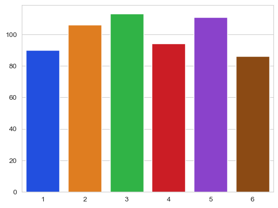

```python
# Simulate 600 die rolls
rolls = [random.randrange(1, 7) for i in range(600)]
values, frequencies = np.unique(rolls, return_counts=True)

# Basic Seaborn bar plot (no labels or titles yet)
sns.set_style("whitegrid")
axes = sns.barplot(x=values, y=frequencies, hue=values, palette="bright", legend=False)
plt.show()
```

### Step 1: Adding a Graph Title

We add a descriptive title using `axes.set_title()`.  
This helps the viewer immediately understand what the chart represents.

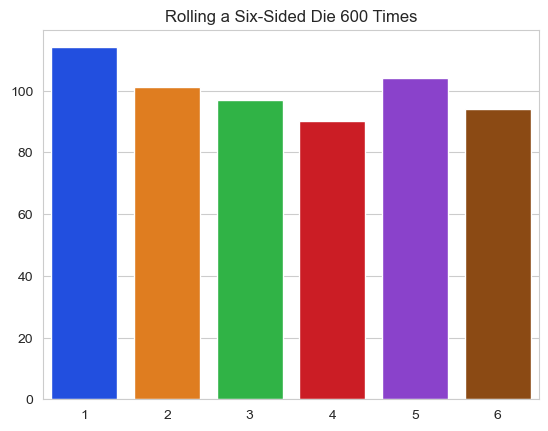

```python
# Simulate 600 die rolls
rolls = [random.randrange(1, 7) for i in range(600)]
values, frequencies = np.unique(rolls, return_counts=True)

# Basic Seaborn bar plot (no labels or titles yet)
sns.set_style("whitegrid")
axes = sns.barplot(x=values, y=frequencies, hue=values, palette="bright", legend=False)

title = f'Rolling a Six-Sided Die {len(rolls):,} Times'
axes.set_title(title)
plt.show()
```

### Step 2: Labeling the Axes

We use `axes.set()` to add labels to both axes:

- **X-axis:** “Die Value”
- **Y-axis:** “Frequency”

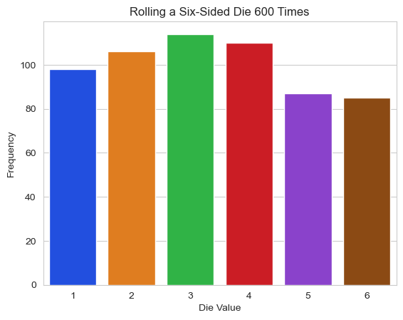

```python
# Simulate 600 die rolls
rolls = [random.randrange(1, 7) for i in range(600)]
values, frequencies = np.unique(rolls, return_counts=True)

# Basic Seaborn bar plot (no labels or titles yet)
sns.set_style("whitegrid")
axes = sns.barplot(x=values, y=frequencies, hue=values, palette="bright", legend=False)

title = f'Rolling a Six-Sided Die {len(rolls):,} Times'
axes.set_title(title)

axes.set(xlabel='Die Value', ylabel='Frequency')
plt.show()
```

### Step 3: Displaying Text Above Each Bar

Now we annotate each bar with:

- the exact number of times each die face appeared, and
- its percentage of the total rolls.

We also make a little extra room above the bars using `set_ylim()`.

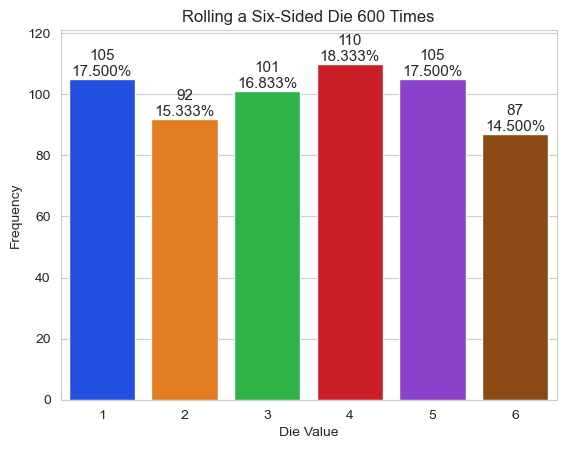

```python
# Simulate 600 die rolls
rolls = [random.randrange(1, 7) for i in range(600)]
values, frequencies = np.unique(rolls, return_counts=True)

# Basic Seaborn bar plot (no labels or titles yet)
sns.set_style("whitegrid")
axes = sns.barplot(x=values, y=frequencies, hue=values, palette="bright", legend=False)

title = f'Rolling a Six-Sided Die {len(rolls):,} Times'
axes.set_title(title)

axes.set(xlabel='Die Value', ylabel='Frequency')

# Make room for text
axes.set_ylim(top=max(frequencies) * 1.10)

# Add text labels above each bar
for bar, frequency in zip(axes.patches, frequencies):
    text_x = bar.get_x() + bar.get_width() / 2.0
    text_y = bar.get_height()
    text = f'{frequency:,}\n{frequency / len(rolls):.3%}'
    axes.text(text_x, text_y, text,
              fontsize=11, ha='center', va='bottom')

plt.show()
```

### Step 4: Customizing the Colors

We already used Seaborn’s `'bright'` color palette, but let’s explore an alternative style.  
Here’s how you can use a **single color** instead, for a more minimalist look.

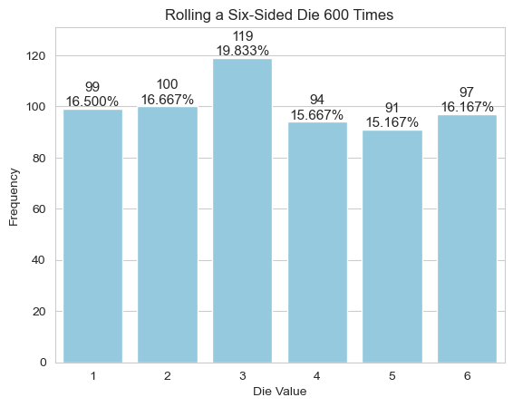

```python
# Simulate 600 die rolls
rolls = [random.randrange(1, 7) for i in range(600)]
values, frequencies = np.unique(rolls, return_counts=True)

# Basic Seaborn bar plot (no labels or titles yet)
sns.set_style("whitegrid")
axes = sns.barplot(x=values, y=frequencies, hue=values, palette="bright", legend=False)

title = f'Rolling a Six-Sided Die {len(rolls):,} Times'
axes.set_title(title)

axes.set(xlabel='Die Value', ylabel='Frequency')

# Make room for text
axes.set_ylim(top=max(frequencies) * 1.10)

# Add text labels above each bar
for bar, frequency in zip(axes.patches, frequencies):
    text_x = bar.get_x() + bar.get_width() / 2.0
    text_y = bar.get_height()
    text = f'{frequency:,}\n{frequency / len(rolls):.3%}'
    axes.text(text_x, text_y, text,
              fontsize=11, ha='center', va='bottom')

plt.clf()  # Clear the previous plot

sns.set_style("whitegrid")
axes = sns.barplot(x=values, y=frequencies, color='skyblue')
axes.set_title(title)
axes.set(xlabel='Die Value', ylabel='Frequency')

axes.set_ylim(top=max(frequencies) * 1.10)
for bar, frequency in zip(axes.patches, frequencies):
    text_x = bar.get_x() + bar.get_width() / 2.0
    text_y = bar.get_height()
    text = f'{frequency:,}\n{frequency / len(rolls):.3%}'
    axes.text(text_x, text_y, text,
              fontsize=11, ha='center', va='bottom')

plt.show()
```

```python
from ipywidgets import interact

def roll_and_plot(n_rolls=600):
    rolls = [random.randrange(1, 7) for _ in range(n_rolls)]
    values, frequencies = np.unique(rolls, return_counts=True)
    sns.set_style('whitegrid')
    axes = sns.barplot(x=values, y=frequencies, hue=values, palette='bright', legend=False)
    axes.set_title(f'Rolling a Six-Sided Die {n_rolls:,} Times')
    axes.set(xlabel='Die Value', ylabel='Frequency')
    axes.set_ylim(top=max(frequencies) * 1.10)
    for bar, frequency in zip(axes.patches, frequencies):
        text_x = bar.get_x() + bar.get_width() / 2.0
        text_y = bar.get_height()
        text = f'{frequency:,}\n{frequency / n_rolls:.3%}'
        axes.text(text_x, text_y, text,
                  fontsize=11, ha='center', va='bottom')
    plt.show()

interact(roll_and_plot, n_rolls=(100, 100000, 100))
```

```
interactive(children=(IntSlider(value=600, description='n_rolls', max=100000, min=100, step=100), Output()), _…
```

```
<function __main__.roll_and_plot(n_rolls=600)>
```

## 5.18 Wrap-Up

This chapter deepened your understanding of **Python sequences**, especially **lists** and **tuples**, and how they form the foundation of data organization and manipulation in Python.

### Lists

- **Creation & Access:** You learned to create lists, access individual elements, and determine their length with `len()`.
- **Mutability:** Lists are **mutable**, meaning you can:
  - Modify existing elements,
  - Add new ones with `append()` or `insert()`,
  - Remove elements with `remove()`, `pop()`, or `del`.
- **Iteration:** Used `for` loops to process list elements one by one.
- **Index Errors:** Accessing invalid indices causes an `IndexError`.
- **Growth & Shrinking:** Lists can dynamically expand or contract during program execution.

### Tuples

- Tuples are **immutable** — once created, their contents cannot be changed.
- You can **unpack** tuple elements into multiple variables easily.
- The **`enumerate()`** function lets you loop through items while also retrieving their indices.
- Tuples can hold any data type, including mutable objects like lists.

### Sequence Operations

All sequence types (lists, tuples, and strings) support **slicing**, which creates new sequences from parts of the original.  
Example:

```
numbers[2:5]  # creates a sublist
```